# Hackathon DIA1

KUOCH Jacky -NICOLAS Kevin - YAYA-OYE Ikhlass // Team IJK

2020-12-26 00:04:06

# Spotify Predictions - A Quick Introduction

In this Machine Learning project, we will try to predict if a certain user will like a track or not. For this, we have a **target** column with a descrete value which is equal to 0 if the user don’t like a song and 1 if he likes it.

The dataset is composed of a **data.csv** file where we have all the informations that we need and a **test.csv** where we don’t have the response and on which we must apply our models.

The evaluation metric for this competition is the **accuracy** of our prediction.  
So let’s see how it has been going for us !

# Load of the libraries

*All the libraries that will need*

```r
library(corrplot) # used to visualize the correlations between the columns of our dataset
library(randomForest) # used for Random Forest model
library(gbm) # used for Boosting model
library(ggplot2)
```

# Load of the dataset

*Loading of the two datasets*

```r
data <- read.csv("data.csv")
test <- read.csv("test.csv")
```

# Data exploration

*Some informations about our dataset*

```r
dim(data) # we have 1817 songs that will help us to build our model and 16 columns
```

```
## [1] 1817   16
```

```r
names(data) # the columns are composed of 13 audio features for a song, a column called target that tells if the user liked the song or not and two columns that give the name and the artist of the song
```

```
##  [1] "acousticness"     "danceability"     "duration_ms"      "energy"
##  [5] "instrumentalness" "key"              "liveness"         "loudness"
##  [9] "mode"             "speechiness"      "tempo"            "time_signature"
## [13] "valence"          "target"           "song_title"       "artist"
```

```r
str(data) # we can see the type of the columns that are either of integer, float or string type.
```

```
## 'data.frame':    1817 obs. of  16 variables:
##  $ acousticness    : num  0.0102 0.199 0.0344 0.604 0.18 0.00479 0.0145 0.0202 0.0481 0.0572 ...
##  $ danceability    : num  0.833 0.743 0.838 0.494 0.678 0.804 0.739 0.266 0.603 0.525 ...
##  $ duration_ms     : num  204600 326933 185707 199413 392893 ...
##  $ energy          : num  0.434 0.359 0.412 0.338 0.561 0.56 0.472 0.348 0.944 0.855 ...
##  $ instrumentalness: num  2.19e-02 6.11e-03 2.34e-04 5.10e-01 5.12e-01 0.00 7.27e-06 6.64e-01 0.00 1.43e-02 ...
##  $ key             : int  2 1 2 5 5 8 1 10 11 5 ...
##  $ liveness        : num  0.165 0.137 0.159 0.0922 0.439 0.164 0.207 0.16 0.342 0.649 ...
##  $ loudness        : num  -8.79 -10.4 -7.15 -15.24 -11.65 ...
##  $ mode            : int  1 1 1 1 0 1 1 0 0 0 ...
##  $ speechiness     : num  0.431 0.0794 0.289 0.0261 0.0694 0.185 0.156 0.0371 0.347 0.0548 ...
##  $ tempo           : num  150.1 160.1 75 86.5 174 ...
##  $ time_signature  : int  4 4 4 4 4 4 4 4 4 3 ...
##  $ valence         : num  0.286 0.588 0.173 0.23 0.904 0.264 0.308 0.393 0.398 0.524 ...
##  $ target          : int  1 1 1 1 1 1 1 1 1 1 ...
##  $ song_title      : chr  "Mask Off" "Redbone" "Xanny Family" "Master Of None" ...
##  $ artist          : chr  "Future" "Childish Gambino" "Future" "Beach House" ...
```

```r
summary(data) # quick summary for each column
```

```
##   acousticness        danceability     duration_ms          energy
##  Min.   :0.0000028   Min.   :0.1220   Min.   :  16042   Min.   :0.0148
##  1st Qu.:0.0090500   1st Qu.:0.5120   1st Qu.: 199500   1st Qu.:0.5640
##  Median :0.0620000   Median :0.6320   Median : 229093   Median :0.7140
##  Mean   :0.1847794   Mean   :0.6185   Mean   : 245760   Mean   :0.6827
##  3rd Qu.:0.2600000   3rd Qu.:0.7370   3rd Qu.: 270333   3rd Qu.:0.8480
##  Max.   :0.9950000   Max.   :0.9840   Max.   :1004627   Max.   :0.9980
##  instrumentalness         key            liveness         loudness
##  Min.   :0.0000000   Min.   : 0.000   Min.   :0.0219   Min.   :-33.097
##  1st Qu.:0.0000000   1st Qu.: 2.000   1st Qu.:0.0923   1st Qu.: -8.372
##  Median :0.0000661   Median : 6.000   Median :0.1270   Median : -6.238
##  Mean   :0.1315299   Mean   : 5.319   Mean   :0.1927   Mean   : -7.046
##  3rd Qu.:0.0510000   3rd Qu.: 9.000   3rd Qu.:0.2510   3rd Qu.: -4.741
##  Max.   :0.9760000   Max.   :11.000   Max.   :0.9530   Max.   : -0.307
##       mode        speechiness          tempo        time_signature
##  Min.   :0.000   Min.   :0.02310   Min.   : 47.86   Min.   :1.000
##  1st Qu.:0.000   1st Qu.:0.03750   1st Qu.:100.05   1st Qu.:4.000
##  Median :1.000   Median :0.05550   Median :121.92   Median :4.000
##  Mean   :0.617   Mean   :0.09272   Mean   :121.55   Mean   :3.968
##  3rd Qu.:1.000   3rd Qu.:0.10800   3rd Qu.:137.64   3rd Qu.:4.000
##  Max.   :1.000   Max.   :0.62200   Max.   :219.33   Max.   :5.000
##     valence           target        song_title           artist
##  Min.   :0.0348   Min.   :0.0000   Length:1817        Length:1817
##  1st Qu.:0.2950   1st Qu.:0.0000   Class :character   Class :character
##  Median :0.4930   Median :1.0000   Mode  :character   Mode  :character
##  Mean   :0.4963   Mean   :0.5036
##  3rd Qu.:0.6900   3rd Qu.:1.0000
##  Max.   :0.9750   Max.   :1.0000
```

# Preprocessing

*Cleaning of the dataset to optimize the prediction*

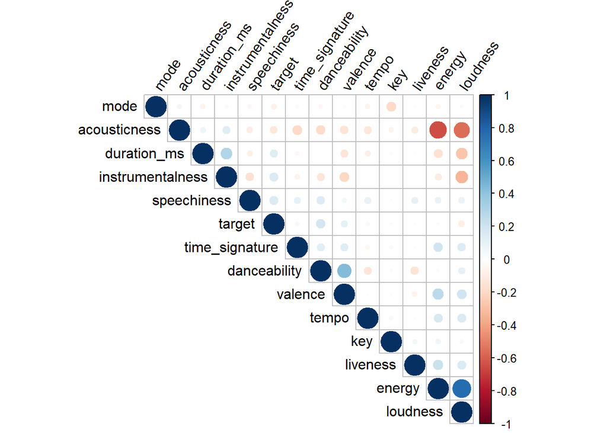

```r
data <- na.omit(data) # we use this function to verify that we don't use NA values in our models

df = data[,-c(15,16)] # we want to delete the columns that have a string type for their values (song_title & artist columns)
tf = test[,-c(14,15)] # same as we did on the data.csv file, we delete the two last columns of the test.csv file because we will not use them for our models

corrplot(cor(df), type = "upper", order = "hclust", tl.col = "black", tl.srt = 55)
```

# Modeling

*Presentation of path to find the best model*

#### Logistic Regression

```r
logistic_model <- glm(target ~ ., family = 'binomial', data = df)
logistic_model.pred <- predict.glm(logistic_model, newdata = tf, type = "response")
logistic_model.pred <- ifelse(logistic_model.pred > 0.5, 1, 0)
```

We knew that it wasn’t the most optimal model so we continue with ensemble classifiers that seemed better for our use.

#### Random Forest

```r
set.seed(703804) # we used the student's number of Ikhlass
rf <- randomForest(target ~ ., data = df, mtry = 4) # 13/3 = 4 after rounding it
rf.pred <- predict(rf, newdata = tf, type = "response")
rf.pred <- ifelse(rf.pred > 0.5, 1, 0)
```

We obtained an accuracy of **75,5%** on kaggle with this model

#### Bagging

```r
set.seed(703804)
bagging <- randomForest(target ~ ., data = df, mtry = 13)
bagging.pred <- predict(bagging, newdata = tf, type = "response")
bagging.pred <- ifelse(bagging.pred > 0.5, 1, 0)
```

We obtained an accuracy of **73%** on kaggle with this model so we saw that this model was less efficient than Random Forest so we continue to search a better model

#### Boosting

```r
set.seed(703804)
boost <- gbm(target ~ ., data = df, distribution = "bernoulli",
            n.trees = 5000, interaction.depth = 4, shrinkage = 0.01)
boost.pred <- predict(boost, newdata = tf, type = "response")
```

```
## Using 5000 trees...
```

```r
boost.pred <- ifelse(boost.pred >0.5, 1, 0)
```

We obtained an accuracy of **76%** on kaggle with this model so we saw that our model improved so we tested to change parameters on this model

With the logistic regression model, we wanted to see which attributes were impactants on the target attribute.

```r
summary(logistic_model)
```

```
##
## Call:
## glm(formula = target ~ ., family = "binomial", data = df)
##
## Deviance Residuals:
##    Min      1Q  Median      3Q     Max
## -2.045  -1.037   0.387   1.045   2.256
##
## Coefficients:
##                    Estimate Std. Error z value Pr(>|z|)
## (Intercept)      -3.880e+00  1.047e+00  -3.706 0.000210 ***
## acousticness     -1.691e+00  2.818e-01  -6.000 1.97e-09 ***
## danceability      1.950e+00  3.869e-01   5.040 4.65e-07 ***
## duration_ms       2.490e-06  7.160e-07   3.477 0.000507 ***
## energy            2.575e-01  4.591e-01   0.561 0.574854
## instrumentalness  1.319e+00  2.259e-01   5.837 5.31e-09 ***
## key              -2.019e-03  1.420e-02  -0.142 0.886958
## liveness          3.340e-01  3.414e-01   0.978 0.327895
## loudness         -1.224e-01  2.488e-02  -4.921 8.60e-07 ***
## mode             -1.819e-01  1.066e-01  -1.707 0.087898 .
## speechiness       4.046e+00  6.333e-01   6.389 1.67e-10 ***
## tempo             4.261e-03  1.978e-03   2.154 0.031254 *
## time_signature   -1.616e-02  2.171e-01  -0.074 0.940646
## valence           8.489e-01  2.493e-01   3.405 0.000662 ***
## ---
## Signif. codes:  0 '***' 0.001 '**' 0.01 '*' 0.05 '.' 0.1 ' ' 1
##
## (Dispersion parameter for binomial family taken to be 1)
##
##     Null deviance: 2518.8  on 1816  degrees of freedom
## Residual deviance: 2247.2  on 1803  degrees of freedom
## AIC: 2275.2
##
## Number of Fisher Scoring iterations: 4
```

```r
subdata = data[,c("acousticness", "danceability", "instrumentalness", "loudness", "speechiness", "valence", "mode", "duration_ms", "tempo","target")]
subtest = test[,c("acousticness", "danceability", "instrumentalness", "loudness", "speechiness", "valence", "mode", "duration_ms", "tempo")]

set.seed(703804)
boost1 <- gbm(target ~ ., data = subdata, distribution = "bernoulli",
            n.trees = 5000, interaction.depth = 4, shrinkage = 0.01)
boost.pred1 <- predict(boost1, newdata = subtest, type = "response")
```

```
## Using 5000 trees...
```

```r
boost.pred1 <- ifelse(boost.pred1 > 0.5, 1, 0)
```

We obtained an accuracy of **72,5%** on kaggle with this model so we saw that this model was less efficient than our previous one with all the features so we kept them all

**At this point, we noticed that we scaled our data but it wasn’t needed in our case. So we tried to predict the testset with all the features and a dataset not scaled**

We proceeded several tests on the hyper parameters of the boosting model. We tried to act on the **cross validation** parameter but it reduced our accuracy everytime so we abandonned it.

```r
set.seed(55100)
boost_final = gbm(target~., data = df, distribution = "bernoulli",
            n.trees = 5000, interaction.depth = 6, shrinkage = 0.004, n.minobsinnode = 6)
boost.pred_final <- predict(boost_final, newdata = tf, type = "response")
```

```
## Using 5000 trees...
```

```r
boost.pred_final <- ifelse(boost.pred_final > 0.5, 1, 0)
```

With the seed that we used from the beginning, we were stuck at 81,5%. We changed arbitrarily the seed by the postal code (55100) of our previous exchange location that is Kuala Lumpur in Malaysia and as if by chance it gave us a better accuracy so we kept it like that :)

It allowed us to achieve a final accuracy of **82%**.

To submit our models, we used this command :

```r
to_be_submitted = data.frame(id = rownames(test), target = boost.pred_final)
#write.csv(to_be_submitted , file = "BoostFinal.csv", row.names = F) # we put this in comments to avoid an issue in our report
```

Here is our final predictions :

```r
to_be_submitted
```

```
##      id target
## 1     1      1
## 2     2      1
## 3     3      0
## 4     4      0
## 5     5      0
## 6     6      1
## 7     7      1
## 8     8      1
## 9     9      0
## 10   10      0
## 11   11      1
## 12   12      0
## 13   13      0
## 14   14      0
```

[output cut: 186 more lines]

Thank you for reading,

[You can check our position in the leaderboard by clicking this link ! We are the team named IJK](https://www.kaggle.com/c/hackathon-machine-learning-65415321065432156413206/leaderboard)